# Vestimenta, confianza y decisiones en un juego de votación

Proyecto final · Introducción a la Ciencia de Datos

2026-11-19

# Presentación

**Pregunta.** ¿Cómo se relacionan los hábitos de vestimenta y la influencia de la ropa sobre la confianza con la seguridad declarada y los cambios de elección en un juego de votación?

**Diseño.** Aplicamos dos instrumentos propios a estudiantes de la Facultad de Ciencias Empresariales y Economía. Una encuesta en Google Forms recoge características de los estudiantes, hábitos de cuidado personal y criterios de vestimenta. Un juego presencial en dos rondas registra una elección entre cuatro actividades (Lógica, Mímica, Dibujo y Memoria) y la seguridad con que se tomó, antes y después de mostrar los resultados del grupo. Un código de participante (P01, P02, …), el mismo en ambos instrumentos, permite vincularlos sin publicar los correos.

**Cuatro N distintos.** A lo largo del informe distinguimos:

| N | Qué cuenta | Dónde se usa |
| --- | --- | --- |
| 39 | Respuestas originales a la encuesta | Descripción y gráficas de la encuesta |
| 36 | Códigos de participante distintos (3 respondieron dos veces) | Una respuesta por participante, para el modelo |
| 34 | Participantes con encuesta y juego | Descripción del juego, asociación y modelo |
| 200 | Filas del juego remuestreadas | Solo para ilustrar la pseudorreplicación; no son personas |

**Organización.** El análisis sigue el orden del archivo de la clase 15 que adaptó el equipo (`codigo/proyecto_encuesta_juego.Rmd`): primero se importan, perfilan, describen y grafican **las respuestas originales**; después se aplica la aumentación de datos; recién entonces se seleccionan las observaciones, se unen las fuentes, se calculan los indicadores de cambio y se ajusta el modelo. La correspondencia con los siete pasos de la pauta de trabajo en equipo es la siguiente:

| Paso de la pauta | Sección de este informe |
| --- | --- |
| 1 · Importar | 1. Importar |
| 2 · Perfilar | 2. Perfilar |
| 3 · Ordenar y limpiar | 5. Preparar (consentimiento, regla para respuestas repetidas) |
| 4 · Unir | 5. Preparar (unión por código) |
| 5 · Generar nueva información | 5. Preparar (indicadores de cambio) |
| 6 · Explorar | 3. Describir, 4. Graficar, 6. Asociación y cambios, 7. Modelo |
| 7 · Comunicar | 8. Comunicar |

Todo el procesamiento está escrito en el código de este documento y se recalcula al tejerlo.

## Paquetes

Las rutas parten de la raíz del proyecto mediante `here()`, como en los ejemplos del curso.

```r
# Si falta alguno, instalarlo una sola vez desde la consola y reiniciar R:
# install.packages(c("dplyr", "readr", "here", "ggplot2", "knitr"))
library(dplyr)
library(readr)
library(here)
library(ggplot2)
library(knitr)

# Formato de números en el texto: coma decimal.
num <- function(x, d = 1) format(round(x, d), decimal.mark = ",", big.mark = ".", nsmall = d)
pct <- function(x, d = 1) paste0(num(100 * x, d), " %")
pval <- function(p) if (p < 0.001) "p < 0,001" else paste0("p = ", num(p, 3))
azul <- "#2B6CB0"
colores_ronda <- c("#A9C3E3", "#2B6CB0")
fuente_encuesta <- "Fuente: encuesta del equipo; todas las respuestas originales."
fuente_juego <- "Fuente: juego del equipo; registros originales."
fuente_cruce <- "Fuente: encuesta y juego unidos por código; una respuesta por participante."
```

# 1. Importar

Los datos fueron generados por el equipo con dos instrumentos: la encuesta, exportada de Google Forms, y el juego, registrado a mano y transcrito a una planilla. El script `codigo/00_anonimizar.R` lee esas exportaciones originales, pasa cada correo a minúsculas y sin espacios externos, asigna un código por orden de aparición y guarda la correspondencia correo–código en `datos/originales/`, carpeta que no se versiona. El informe usa únicamente los cuatro CSV resultantes de `datos/`, que no contienen correos.

```r
encuesta_cruda <- read_csv(here("datos", "encuesta.csv"), show_col_types = FALSE)
juego_crudo    <- read_csv(here("datos", "juego.csv"), show_col_types = FALSE)
dicc_encuesta  <- read_csv(here("datos", "diccionario_encuesta.csv"), show_col_types = FALSE)
dicc_juego     <- read_csv(here("datos", "diccionario_juego.csv"), show_col_types = FALSE)

tibble(
  archivo = c("encuesta.csv", "juego.csv", "diccionario_encuesta.csv", "diccionario_juego.csv"),
  filas = c(nrow(encuesta_cruda), nrow(juego_crudo), nrow(dicc_encuesta), nrow(dicc_juego)),
  columnas = c(ncol(encuesta_cruda), ncol(juego_crudo), ncol(dicc_encuesta), ncol(dicc_juego))
) |> kable(caption = "Archivos importados")
```

Archivos importados

| archivo | filas | columnas |
| --- | --- | --- |
| encuesta.csv | 39 | 34 |
| juego.csv | 34 | 5 |
| diccionario_encuesta.csv | 34 | 6 |
| diccionario_juego.csv | 5 | 5 |

**Instrumento del juego.** En la primera ronda cada participante eligió una actividad (1 = Lógica, 2 = Mímica, 3 = Dibujo, 4 = Memoria) y declaró la seguridad de su elección de 1 (mínima) a 5 (máxima). Luego se mostró la votación del grupo y se repitieron la elección y la seguridad.

```r
kable(dicc_juego, caption = "Diccionario del juego")
```

Diccionario del juego

| variable | descripcion | tipo | codificacion | faltantes |
| --- | --- | --- | --- | --- |
| id | Código de participante (P01, P02, …), el mismo que en la encuesta | Texto nominal | P + número de dos cifras | No admite |
| ronda1_eleccion | Actividad elegida antes de mostrar resultados | Categórica nominal | 1=Lógica; 2=Mímica; 3=Dibujo; 4=Memoria | Vacío sin respuesta |
| ronda1_seguridad | Seguridad de la elección antes de mostrar resultados | Ordinal | 1=Mínima; 2; 3; 4; 5=Máxima | Vacío sin respuesta |
| ronda2_eleccion | Actividad elegida luego de conocer los resultados del grupo | Categórica nominal | 1=Lógica; 2=Mímica; 3=Dibujo; 4=Memoria | Vacío sin respuesta |
| ronda2_seguridad | Seguridad de la elección de la segunda ronda | Ordinal | 1=Mínima; 2; 3; 4; 5=Máxima | Vacío sin respuesta |

**Alcance de la fuente.** Una fila de la encuesta es **una respuesta**, no necesariamente una persona distinta; una fila del juego contiene las dos rondas de un código. No registramos el número de personas invitadas ni el de quienes rechazaron participar, por lo que no se puede calcular una tasa de respuesta. Los archivos tampoco incluyen una columna que distinga registros observados de registros sintéticos; en el paso 8 lo señalamos como límite.

# 2. Perfilar

El perfilado diagnostica sin modificar las tablas: tipo, valores distintos, faltantes y rango de cada variable.

```r
# Funciones, sapply(), is.na(), unique(), min() y max(): clases 3, 5, 7 y 9.
perfil <- function(datos) {
  tibble(
    variable  = names(datos),
    tipo      = sapply(datos, function(x) class(x)[1]),
    distintos = sapply(datos, function(x) length(unique(x[!is.na(x)]))),
    faltantes = sapply(datos, function(x) sum(is.na(x))),
    minimo    = sapply(datos, function(x)
      if (is.numeric(x) && any(!is.na(x))) min(x, na.rm = TRUE) else NA_real_),
    maximo    = sapply(datos, function(x)
      if (is.numeric(x) && any(!is.na(x))) max(x, na.rm = TRUE) else NA_real_)
  )
}
kable(perfil(encuesta_cruda), caption = "Perfil de la encuesta original")
```

Perfil de la encuesta original

| variable | tipo | distintos | faltantes | minimo | maximo |
| --- | --- | --- | --- | --- | --- |
| id | character | 36 | 0 | NA | NA |
| fecha_respuesta | character | 39 | 0 | NA | NA |
| consentimiento | numeric | 1 | 0 | 1 | 1 |
| sexo | numeric | 2 | 0 | 0 | 1 |
| edad | numeric | 6 | 0 | 19 | 26 |
| anio_carrera | numeric | 4 | 0 | 2 | 5 |
| carrera | numeric | 5 | 0 | 1 | 6 |
| carrera_otro_detalle | logical | 0 | 39 | NA | NA |
| frec_peluqueria | numeric | 6 | 0 | 1 | 8 |
| se_peina | numeric | 2 | 0 | 0 | 1 |
| piensa_ropa_fac | numeric | 2 | 0 | 0 | 1 |
| tiempo_ropa_fac | numeric | 4 | 0 | 0 | 3 |
| fac_comodidad | numeric | 2 | 0 | 0 | 1 |
| fac_clima | numeric | 2 | 0 | 0 | 1 |
| fac_estilo | numeric | 2 | 0 | 0 | 1 |
| fac_ropa_limpia | numeric | 2 | 0 | 0 | 1 |
| fac_como_me_veo | numeric | 2 | 0 | 0 | 1 |
| fac_como_me_ven | numeric | 2 | 0 | 0 | 1 |
| fac_formalidad | numeric | 2 | 0 | 0 | 1 |
| tiempo_arreglo_fac | numeric | 3 | 0 | 1 | 3 |
| piensa_ropa_trab | numeric | 2 | 0 | 0 | 1 |
| tiempo_ropa_trab | numeric | 6 | 0 | 0 | 6 |
| trab_comodidad | numeric | 2 | 0 | 0 | 1 |
| trab_clima | numeric | 2 | 0 | 0 | 1 |
| trab_estilo | numeric | 2 | 0 | 0 | 1 |
| trab_ropa_limpia | numeric | 2 | 0 | 0 | 1 |
| trab_como_me_veo | numeric | 2 | 0 | 0 | 1 |
| trab_como_me_ven | numeric | 2 | 0 | 0 | 1 |
| trab_formalidad | numeric | 2 | 0 | 0 | 1 |
| frec_compra_ropa | numeric | 4 | 0 | 1 | 4 |
| importancia_marca | numeric | 3 | 0 | 1 | 3 |
| confianza_ropa | numeric | 3 | 0 | 1 | 3 |
| cambia_segun_personas | numeric | 2 | 0 | 0 | 1 |
| repite_outfit | numeric | 2 | 0 | 0 | 1 |

```r
kable(perfil(juego_crudo), caption = "Perfil del juego original")
```

Perfil del juego original

| variable | tipo | distintos | faltantes | minimo | maximo |
| --- | --- | --- | --- | --- | --- |
| id | character | 34 | 0 | NA | NA |
| ronda1_eleccion | numeric | 4 | 0 | 1 | 4 |
| ronda1_seguridad | numeric | 5 | 0 | 1 | 5 |
| ronda2_eleccion | numeric | 4 | 0 | 1 | 4 |
| ronda2_seguridad | numeric | 3 | 0 | 3 | 5 |

```r
repeticiones <- encuesta_cruda |> count(id) |> count(n, name = "codigos")
tibble(
  control = c("Filas idénticas en la encuesta",
              "Códigos con dos respuestas en la encuesta",
              "Códigos repetidos en el juego",
              "Respuestas sin consentimiento",
              "Edad fuera de 15 a 80",
              "Peluquería fuera de 1 a 10",
              "Confianza en la ropa fuera de 1 a 3",
              "Elección fuera de 1 a 4 (ronda 1 o 2)",
              "Seguridad fuera de 1 a 5 (ronda 1 o 2)"),
  casos = c(sum(duplicated(encuesta_cruda)),
            sum(repeticiones$codigos[repeticiones$n > 1]),
            sum(duplicated(juego_crudo$id)),
            sum(encuesta_cruda$consentimiento != 1, na.rm = TRUE),
            sum(encuesta_cruda$edad < 15 | encuesta_cruda$edad > 80, na.rm = TRUE),
            sum(!encuesta_cruda$frec_peluqueria %in% 1:10),
            sum(!encuesta_cruda$confianza_ropa %in% 1:3),
            sum(!juego_crudo$ronda1_eleccion %in% 1:4) + sum(!juego_crudo$ronda2_eleccion %in% 1:4),
            sum(!juego_crudo$ronda1_seguridad %in% 1:5) + sum(!juego_crudo$ronda2_seguridad %in% 1:5))
) |> kable(caption = "Controles de calidad sobre los datos originales")
```

Controles de calidad sobre los datos originales

| control | casos |
| --- | --- |
| Filas idénticas en la encuesta | 0 |
| Códigos con dos respuestas en la encuesta | 3 |
| Códigos repetidos en el juego | 0 |
| Respuestas sin consentimiento | 0 |
| Edad fuera de 15 a 80 | 0 |
| Peluquería fuera de 1 a 10 | 0 |
| Confianza en la ropa fuera de 1 a 3 | 0 |
| Elección fuera de 1 a 4 (ronda 1 o 2) | 0 |
| Seguridad fuera de 1 a 5 (ronda 1 o 2) | 0 |

**Lo que encontró el perfilado:**

- **Respuestas repetidas.** La encuesta tiene 39 respuestas y 36 códigos distintos. No hay filas idénticas: son respuestas distintas de un mismo participante. El tratamiento se decide en el paso 5, después de describir y aumentar.
- **El 0 es una respuesta válida** en las variables binarias y en `tiempo_ropa_fac` (“No lo hago”); no se reemplaza por NA.
- **Categorías guardadas como números.** Un 7 en peluquería significa “1 vez al mes”, no siete visitas; las distancias entre códigos no son iguales.
- **`carrera_otro_detalle` está vacía** en todas las filas porque el CSV exportado no incluye ese campo; nadie eligió “Otro” en carrera.
- **Ningún valor fuera de rango.**

# 3. Describir las respuestas originales

En esta etapa describimos **todas las respuestas tal como están guardadas**: no se eliminan repetidas, no se elige una respuesta por código y no se calculan cambios entre rondas. Las copias de presentación solo agregan las etiquetas del diccionario.

```r
etq_peluqueria <- c("Más de 6 meses", "Cada 6 meses", "Cada 5 meses", "Cada 4 meses",
                    "Cada 3 meses", "Cada 2 meses", "1 vez al mes", "2 veces al mes",
                    "1 vez a la semana", "Más de 1 vez a la semana")
etq_confianza <- c("No influye", "Impacto moderado", "Influye significativamente")
etq_tiempo <- c("No lo hago", "Unas horas/minutos antes", "La noche anterior",
                "Un día antes", "Dos días antes", "La semana previa", "Un mes antes")
etq_actividad <- c("Lógica", "Mímica", "Dibujo", "Memoria")
binarias <- c("se_peina", "piensa_ropa_fac", "fac_comodidad", "fac_clima", "fac_estilo",
              "fac_ropa_limpia", "fac_como_me_veo", "fac_como_me_ven", "fac_formalidad",
              "piensa_ropa_trab", "trab_comodidad", "trab_clima", "trab_estilo",
              "trab_ropa_limpia", "trab_como_me_veo", "trab_como_me_ven", "trab_formalidad",
              "cambia_segun_personas", "repite_outfit")

encuesta_desc <- encuesta_cruda |>
  mutate(
    across(all_of(binarias), ~ factor(.x, levels = c(0, 1), labels = c("No", "Sí"))),
    sexo = factor(sexo, levels = c(0, 1), labels = c("Femenino", "Masculino")),
    anio_carrera = factor(anio_carrera, levels = 1:6, labels = paste0(1:6, ".º")),
    carrera = factor(carrera, levels = 1:8, labels = c("Finanzas",
      "Ciencia de Datos para Negocios", "Administración de Empresas",
      "Negocios Internacionales", "Economía", "Contador Público", "Marketing", "Otro")),
    frec_peluqueria = factor(frec_peluqueria, levels = 1:10, labels = etq_peluqueria),
    tiempo_ropa_fac = factor(tiempo_ropa_fac, levels = 0:6, labels = etq_tiempo),
    tiempo_ropa_trab = factor(tiempo_ropa_trab, levels = 0:6, labels = etq_tiempo),
    tiempo_arreglo_fac = factor(tiempo_arreglo_fac, levels = 1:3,
      labels = c("Menos de 15 minutos", "Entre 15 y 30 minutos", "Más de 1 hora")),
    frec_compra_ropa = factor(frec_compra_ropa, levels = 1:5,
      labels = c("Una vez cada más de 2 meses", "Una vez cada 2 meses", "Una vez por mes",
                 "Una vez cada 2 semanas", "Todas las semanas")),
    importancia_marca = factor(importancia_marca, levels = 1:3,
      labels = c("Poca", "Moderada", "Mucha")),
    confianza_ropa = factor(confianza_ropa, levels = 1:3, labels = etq_confianza)
  )

juego_desc <- juego_crudo |>
  mutate(across(c(ronda1_eleccion, ronda2_eleccion),
                ~ factor(.x, levels = 1:4, labels = etq_actividad)),
         across(c(ronda1_seguridad, ronda2_seguridad),
                ~ factor(.x, levels = 1:5)))
```

## Caracterización

```r
encuesta_desc |> count(carrera) |> mutate(porcentaje = round(100 * n / sum(n), 1)) |>
  kable(caption = "Carrera, sobre todas las respuestas")
```

Carrera, sobre todas las respuestas

| carrera | n | porcentaje |
| --- | --- | --- |
| Finanzas | 15 | 38.5 |
| Ciencia de Datos para Negocios | 19 | 48.7 |
| Administración de Empresas | 1 | 2.6 |
| Economía | 2 | 5.1 |
| Contador Público | 2 | 5.1 |

Se registraron 39 respuestas: 24 de sexo masculino y 15 de sexo femenino, con edades de 19 a 26 años (mediana 21). **Predominan Ciencia de Datos para Negocios (19) y Finanzas (15), pero también respondieron estudiantes de otras carreras** (5 respuestas entre Economía, Contador Público y Administración). La muestra no es aleatoria: los porcentajes describen las respuestas recibidas y no a los estudiantes de la universidad.

En cuidado personal, el 71,8 % se peina antes de ir a la universidad, el 56,4 % se arregla en menos de 15 minutos y el 30,8 % piensa la ropa de facultad con antelación. El 71,8 % dice que la ropa tiene un impacto moderado sobre su confianza y el 20,5 % que influye significativamente; el 53,8 % adapta la ropa según con quién estará y el 69,2 % repite outfit sin problema. En compras, el 48,7 % compra ropa una vez cada más de dos meses y el 66,7 % le da una importancia moderada a la marca.

Para ir a facultad, el 7,7 % marca la **formalidad exigida** como criterio. Marcar ese criterio **no significa usar ropa formal**: esa conducta no se preguntó. Como se podían marcar varios criterios, sus porcentajes no suman 100.

## Tabla descriptiva de todas las preguntas

La tabla incluye todas las preguntas de la encuesta, con el total y el desglose por sexo. **No agregamos p-valores**: hay códigos con dos respuestas, por lo que las filas no son personas independientes y un test sobre ellas sería incorrecto.

```r
n_pct <- function(x, valor) {
  n <- sum(x == valor, na.rm = TRUE)
  paste0(n, " (", num(100 * n / sum(!is.na(x)), 1), ")")
}
filas_variable <- function(var, etiqueta) {
  x <- encuesta_desc[[var]]
  s <- encuesta_desc$sexo
  if (is.numeric(x)) {
    md <- function(v) paste0(num(mean(v), 1), " (", num(sd(v), 1), ")")
    return(tibble(Pregunta = etiqueta, Respuesta = "Media (DE)", Total = md(x),
                  Femenino = md(x[s == "Femenino"]), Masculino = md(x[s == "Masculino"])))
  }
  niveles <- if (identical(levels(x), c("No", "Sí"))) "Sí" else levels(x)[table(x) > 0]
  bind_rows(lapply(seq_along(niveles), function(i) {
    l <- niveles[i]
    tibble(Pregunta = if (i == 1) etiqueta else "", Respuesta = l,
           Total = n_pct(x, l), Femenino = n_pct(x[s == "Femenino"], l),
           Masculino = n_pct(x[s == "Masculino"], l))
  }))
}
preguntas <- c(
  edad = "Edad (años)", anio_carrera = "Año de carrera", carrera = "Carrera",
  frec_peluqueria = "Frecuencia de peluquería", se_peina = "Se peina antes de venir",
  tiempo_arreglo_fac = "Tiempo para arreglarse",
  piensa_ropa_fac = "Piensa con antelación la ropa de facultad",
  tiempo_ropa_fac = "Cuánto antes, facultad",
  fac_clima = "Facultad: clima", fac_estilo = "Facultad: estilo y combinación",
  fac_comodidad = "Facultad: comodidad", fac_como_me_veo = "Facultad: cómo me veo",
  fac_como_me_ven = "Facultad: cómo me ven", fac_formalidad = "Facultad: formalidad exigida",
  fac_ropa_limpia = "Facultad: lo primero limpio",
  piensa_ropa_trab = "Piensa con antelación la ropa de trabajo",
  tiempo_ropa_trab = "Cuánto antes, trabajo",
  trab_clima = "Trabajo: clima", trab_estilo = "Trabajo: estilo y combinación",
  trab_comodidad = "Trabajo: comodidad", trab_como_me_veo = "Trabajo: cómo me veo",
  trab_como_me_ven = "Trabajo: cómo me ven", trab_formalidad = "Trabajo: formalidad exigida",
  trab_ropa_limpia = "Trabajo: lo primero limpio",
  frec_compra_ropa = "Frecuencia de compra de ropa", importancia_marca = "Importancia de la marca",
  confianza_ropa = "Influencia de la ropa en la confianza",
  cambia_segun_personas = "Cambia la ropa según con quién estará",
  repite_outfit = "Repite outfit sin problema")
tabla <- bind_rows(lapply(names(preguntas), function(v) filas_variable(v, preguntas[[v]])))
names(tabla)[3:5] <- c(paste0("Total (", nrow(encuesta_desc), ")"),
                       paste0("Femenino (", sum(encuesta_desc$sexo == "Femenino"), ")"),
                       paste0("Masculino (", sum(encuesta_desc$sexo == "Masculino"), ")"))
kable(tabla, format = "html", table.attr = 'class="table desc"', align = c("l", "l", "r", "r", "r"),
      caption = "Todas las preguntas de la encuesta: n (%) sobre las respuestas originales")
```

Todas las preguntas de la encuesta: n (%) sobre las respuestas originales

| Pregunta | Respuesta | Total (39) | Femenino (15) | Masculino (24) |
| --- | --- | --- | --- | --- |
| Edad (años) | Media (DE) | 20,8 (1,5) | 20,8 (1,4) | 20,8 (1,5) |
| Año de carrera | 2.º | 18 (46,2) | 5 (33,3) | 13 (54,2) |
|  | 3.º | 12 (30,8) | 4 (26,7) | 8 (33,3) |
|  | 4.º | 7 (17,9) | 5 (33,3) | 2 (8,3) |
|  | 5.º | 2 (5,1) | 1 (6,7) | 1 (4,2) |
| Carrera | Finanzas | 15 (38,5) | 7 (46,7) | 8 (33,3) |
|  | Ciencia de Datos para Negocios | 19 (48,7) | 4 (26,7) | 15 (62,5) |
|  | Administración de Empresas | 1 (2,6) | 1 (6,7) | 0 (0,0) |
|  | Economía | 2 (5,1) | 1 (6,7) | 1 (4,2) |
|  | Contador Público | 2 (5,1) | 2 (13,3) | 0 (0,0) |
| Frecuencia de peluquería | Más de 6 meses | 8 (20,5) | 7 (46,7) | 1 (4,2) |
|  | Cada 6 meses | 3 (7,7) | 3 (20,0) | 0 (0,0) |
|  | Cada 3 meses | 8 (20,5) | 5 (33,3) | 3 (12,5) |
|  | Cada 2 meses | 8 (20,5) | 0 (0,0) | 8 (33,3) |
|  | 1 vez al mes | 10 (25,6) | 0 (0,0) | 10 (41,7) |
|  | 2 veces al mes | 2 (5,1) | 0 (0,0) | 2 (8,3) |
| Se peina antes de venir | Sí | 28 (71,8) | 10 (66,7) | 18 (75,0) |
| Tiempo para arreglarse | Menos de 15 minutos | 22 (56,4) | 6 (40,0) | 16 (66,7) |
|  | Entre 15 y 30 minutos | 16 (41,0) | 8 (53,3) | 8 (33,3) |
|  | Más de 1 hora | 1 (2,6) | 1 (6,7) | 0 (0,0) |
| Piensa con antelación la ropa de facultad | Sí | 12 (30,8) | 7 (46,7) | 5 (20,8) |
| Cuánto antes, facultad | No lo hago | 13 (33,3) | 2 (13,3) | 11 (45,8) |
|  | Unas horas/minutos antes | 12 (30,8) | 8 (53,3) | 4 (16,7) |
|  | La noche anterior | 13 (33,3) | 5 (33,3) | 8 (33,3) |
|  | Un día antes | 1 (2,6) | 0 (0,0) | 1 (4,2) |
| Facultad: clima | Sí | 27 (69,2) | 12 (80,0) | 15 (62,5) |
| Facultad: estilo y combinación | Sí | 27 (69,2) | 12 (80,0) | 15 (62,5) |
| Facultad: comodidad | Sí | 21 (53,8) | 4 (26,7) | 17 (70,8) |
| Facultad: cómo me veo | Sí | 19 (48,7) | 6 (40,0) | 13 (54,2) |
| Facultad: cómo me ven | Sí | 5 (12,8) | 3 (20,0) | 2 (8,3) |
| Facultad: formalidad exigida | Sí | 3 (7,7) | 2 (13,3) | 1 (4,2) |
| Facultad: lo primero limpio | Sí | 2 (5,1) | 1 (6,7) | 1 (4,2) |
| Piensa con antelación la ropa de trabajo | Sí | 24 (61,5) | 10 (66,7) | 14 (58,3) |
| Cuánto antes, trabajo | No lo hago | 10 (25,6) | 3 (20,0) | 7 (29,2) |
|  | Unas horas/minutos antes | 5 (12,8) | 3 (20,0) | 2 (8,3) |
|  | La noche anterior | 19 (48,7) | 8 (53,3) | 11 (45,8) |
|  | Un día antes | 3 (7,7) | 1 (6,7) | 2 (8,3) |
|  | La semana previa | 1 (2,6) | 0 (0,0) | 1 (4,2) |
|  | Un mes antes | 1 (2,6) | 0 (0,0) | 1 (4,2) |
| Trabajo: clima | Sí | 27 (69,2) | 12 (80,0) | 15 (62,5) |
| Trabajo: estilo y combinación | Sí | 23 (59,0) | 13 (86,7) | 10 (41,7) |
| Trabajo: comodidad | Sí | 10 (25,6) | 3 (20,0) | 7 (29,2) |
| Trabajo: cómo me veo | Sí | 16 (41,0) | 6 (40,0) | 10 (41,7) |
| Trabajo: cómo me ven | Sí | 11 (28,2) | 3 (20,0) | 8 (33,3) |
| Trabajo: formalidad exigida | Sí | 28 (71,8) | 9 (60,0) | 19 (79,2) |
| Trabajo: lo primero limpio | Sí | 1 (2,6) | 1 (6,7) | 0 (0,0) |
| Frecuencia de compra de ropa | Una vez cada más de 2 meses | 19 (48,7) | 2 (13,3) | 17 (70,8) |
|  | Una vez cada 2 meses | 10 (25,6) | 4 (26,7) | 6 (25,0) |
|  | Una vez por mes | 7 (17,9) | 6 (40,0) | 1 (4,2) |
|  | Una vez cada 2 semanas | 3 (7,7) | 3 (20,0) | 0 (0,0) |
| Importancia de la marca | Poca | 9 (23,1) | 2 (13,3) | 7 (29,2) |
|  | Moderada | 26 (66,7) | 12 (80,0) | 14 (58,3) |
|  | Mucha | 4 (10,3) | 1 (6,7) | 3 (12,5) |
| Influencia de la ropa en la confianza | No influye | 3 (7,7) | 0 (0,0) | 3 (12,5) |
|  | Impacto moderado | 28 (71,8) | 9 (60,0) | 19 (79,2) |
|  | Influye significativamente | 8 (20,5) | 6 (40,0) | 2 (8,3) |
| Cambia la ropa según con quién estará | Sí | 21 (53,8) | 9 (60,0) | 12 (50,0) |
| Repite outfit sin problema | Sí | 27 (69,2) | 6 (40,0) | 21 (87,5) |

**Diferencias descriptivas por sexo.** En estas respuestas, el 47 % de las de sexo femenino va a la peluquería cada más de seis meses y el 42 % de las de sexo masculino, una vez por mes. “Influye significativamente” lo marca el 40 % de las respuestas femeninas y el 8 % de las masculinas; repite outfit sin problema el 88 % de las masculinas y el 40 % de las femeninas. Son diferencias en las respuestas recibidas, sin test: no permiten afirmar que existan en otra muestra.

## El juego: las dos rondas

```r
fila_juego <- function(var, etiqueta) {
  x <- juego_desc[[var]]
  tibble(Pregunta = c(etiqueta, rep("", nlevels(x) - 1)), Respuesta = levels(x),
         `n (%)` = sapply(levels(x), function(l) n_pct(x, l)))
}
bind_rows(fila_juego("ronda1_eleccion", "Ronda 1: actividad"),
          fila_juego("ronda2_eleccion", "Ronda 2: actividad"),
          fila_juego("ronda1_seguridad", "Ronda 1: seguridad (1 a 5)"),
          fila_juego("ronda2_seguridad", "Ronda 2: seguridad (1 a 5)")) |>
  kable(caption = paste0("Respuestas originales del juego (", nrow(juego_crudo), " registros)"))
```

Respuestas originales del juego (34 registros)

| Pregunta | Respuesta | n (%) |
| --- | --- | --- |
| Ronda 1: actividad | Lógica | 10 (29,4) |
|  | Mímica | 9 (26,5) |
|  | Dibujo | 9 (26,5) |
|  | Memoria | 6 (17,6) |
| Ronda 2: actividad | Lógica | 12 (35,3) |
|  | Mímica | 8 (23,5) |
|  | Dibujo | 10 (29,4) |
|  | Memoria | 4 (11,8) |
| Ronda 1: seguridad (1 a 5) | 1 | 1 (2,9) |
|  | 2 | 3 (8,8) |
|  | 3 | 7 (20,6) |
|  | 4 | 10 (29,4) |
|  | 5 | 13 (38,2) |
| Ronda 2: seguridad (1 a 5) | 1 | 0 (0,0) |
|  | 2 | 0 (0,0) |
|  | 3 | 2 (5,9) |
|  | 4 | 5 (14,7) |
|  | 5 | 27 (79,4) |

El juego aporta 34 registros con las dos rondas; no se cuentan como el doble de personas. En la primera ronda ninguna actividad tuvo mayoría: la más votada, Lógica, reunió 10 de 34 (29,4 %). En la segunda ronda, **27 de 34 registros (79,4 %) declaran la seguridad máxima**, frente a 13 (38,2 %) en la primera.

Antes de construir indicadores, la tabla cruzada de ambas elecciones ya muestra quién mantuvo su actividad (diagonal) y hacia dónde fueron los demás:

```r
table(`Ronda 1` = juego_desc$ronda1_eleccion, `Ronda 2` = juego_desc$ronda2_eleccion) |>
  as.data.frame.matrix() |>
  kable(caption = "Actividad en la ronda 1 (filas) y en la ronda 2 (columnas)")
```

Actividad en la ronda 1 (filas) y en la ronda 2 (columnas)

|  | Lógica | Mímica | Dibujo | Memoria |
| --- | --- | --- | --- | --- |
| Lógica | 7 | 0 | 3 | 0 |
| Mímica | 2 | 7 | 0 | 0 |
| Dibujo | 2 | 0 | 6 | 1 |
| Memoria | 1 | 1 | 1 | 3 |

# 4. Graficar las respuestas originales

Todas las gráficas de esta sección usan preguntas originales, sin seleccionar una respuesta por código ni calcular indicadores. Las etiquetas muestran porcentajes y el pie de cada gráfica indica sobre qué total se calculan.

## Frecuencia de peluquería

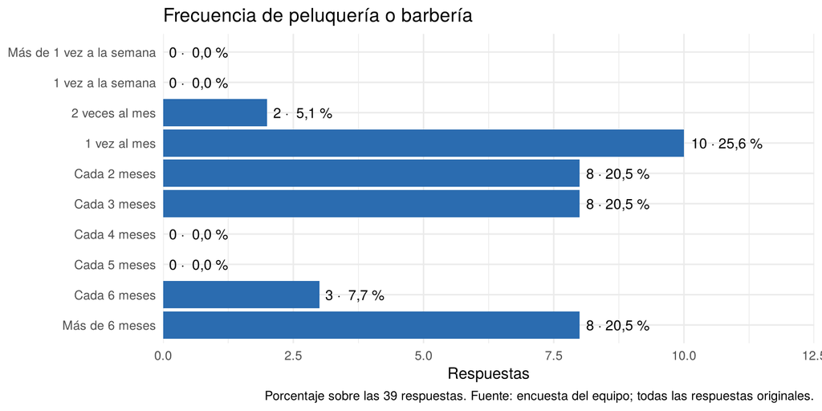

```r
encuesta_desc |> count(frec_peluqueria, .drop = FALSE) |>
  mutate(porcentaje = 100 * n / sum(n)) |>
  ggplot(aes(x = frec_peluqueria, y = n)) +
  geom_col(fill = azul) +
  geom_text(aes(label = paste0(n, " · ", num(porcentaje, 1), " %")), hjust = -0.1, size = 3.5) +
  coord_flip() + theme_minimal() +
  scale_y_continuous(expand = expansion(mult = c(0, 0.25))) +
  labs(title = "Frecuencia de peluquería o barbería", x = NULL, y = "Respuestas",
       caption = paste("Porcentaje sobre las", nrow(encuesta_cruda), "respuestas.", fuente_encuesta))
```

La opción más frecuente es una vez por mes; las barras son categorías de la pregunta, no cantidades de visitas.

## Edad según frecuencia de peluquería

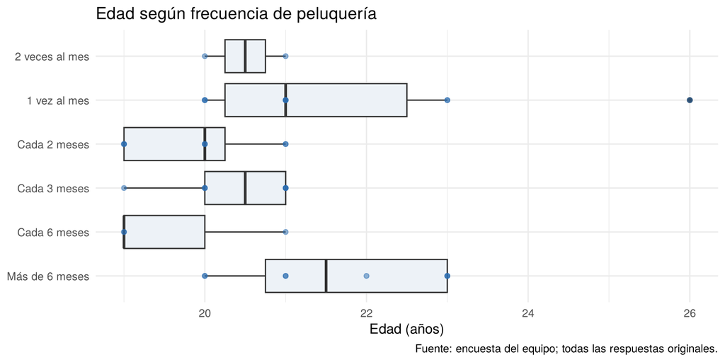

```r
encuesta_desc |> filter(!is.na(frec_peluqueria)) |>
  ggplot(aes(x = frec_peluqueria, y = edad)) +
  geom_boxplot(fill = "#EDF2F7") +
  geom_point(alpha = 0.5, color = azul) +
  coord_flip() + theme_minimal() +
  labs(title = "Edad según frecuencia de peluquería", x = NULL, y = "Edad (años)",
       caption = fuente_encuesta)
```

Usamos cajas y no una línea porque los códigos de frecuencia no están a distancias iguales. Con grupos de 2 a 10 respuestas y edades concentradas entre 19 y 23 años, no se observa un patrón claro.

## Influencia de la ropa en la confianza según adaptación al contexto

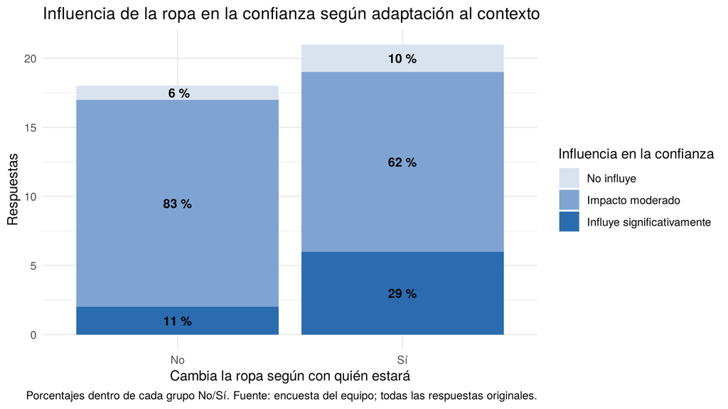

```r
resumen_confianza <- encuesta_desc |>
  count(cambia_segun_personas, confianza_ropa) |>
  group_by(cambia_segun_personas) |>
  mutate(porcentaje = 100 * n / sum(n)) |> ungroup()

ggplot(resumen_confianza, aes(x = cambia_segun_personas, y = n, fill = confianza_ropa)) +
  geom_col() +
  geom_text(aes(label = paste0(num(porcentaje, 0), " %")),
            position = position_stack(vjust = 0.5), size = 3.5, fontface = "bold") +
  scale_fill_manual(values = c("#D9E3EF", "#7FA4D3", azul)) +
  theme_minimal() +
  labs(title = "Influencia de la ropa en la confianza según adaptación al contexto",
       x = "Cambia la ropa según con quién estará", y = "Respuestas",
       fill = "Influencia en la confianza",
       caption = paste("Porcentajes dentro de cada grupo No/Sí.", fuente_encuesta))
```

Entre quienes adaptan la ropa al contexto, “influye significativamente” aparece con más frecuencia (29 % frente a 11 %), aunque en ambos grupos predomina el impacto moderado. Es una descripción, sin test.

## Elecciones del juego en cada ronda

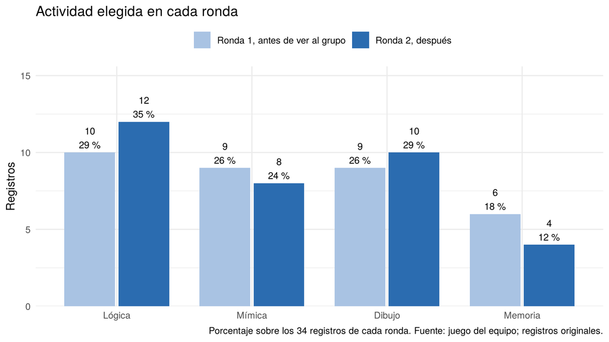

```r
largo <- bind_rows(
  juego_desc |> transmute(ronda = "Ronda 1, antes de ver al grupo",
                          actividad = ronda1_eleccion,
                          seguridad = juego_crudo$ronda1_seguridad),
  juego_desc |> transmute(ronda = "Ronda 2, después",
                          actividad = ronda2_eleccion,
                          seguridad = juego_crudo$ronda2_seguridad)
)
largo |> count(ronda, actividad) |>
  group_by(ronda) |> mutate(porcentaje = 100 * n / sum(n)) |> ungroup() |>
  ggplot(aes(x = actividad, y = n, fill = ronda)) +
  geom_col(position = position_dodge(width = 0.8), width = 0.75) +
  geom_text(aes(label = paste0(n, "\n", num(porcentaje, 0), " %")),
            position = position_dodge(width = 0.8), vjust = -0.2, size = 3.2) +
  scale_fill_manual(values = colores_ronda) +
  scale_y_continuous(expand = expansion(mult = c(0, 0.3))) +
  theme_minimal() + theme(legend.position = "top") +
  labs(title = "Actividad elegida en cada ronda", x = NULL, y = "Registros", fill = NULL,
       caption = paste("Porcentaje sobre los", nrow(juego_crudo), "registros de cada ronda.",
                       fuente_juego))
```

## Seguridad declarada en cada ronda

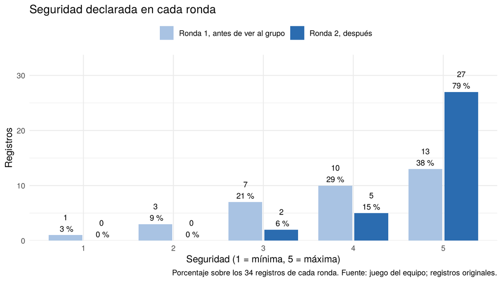

```r
largo |> count(ronda, seguridad = factor(seguridad, levels = 1:5), .drop = FALSE) |>
  group_by(ronda) |> mutate(porcentaje = 100 * n / sum(n)) |> ungroup() |>
  ggplot(aes(x = seguridad, y = n, fill = ronda)) +
  geom_col(position = position_dodge(width = 0.8), width = 0.75) +
  geom_text(aes(label = paste0(n, "\n", num(porcentaje, 0), " %")),
            position = position_dodge(width = 0.8), vjust = -0.2, size = 3.2) +
  scale_fill_manual(values = colores_ronda) +
  scale_y_continuous(expand = expansion(mult = c(0, 0.25))) +
  theme_minimal() + theme(legend.position = "top") +
  labs(title = "Seguridad declarada en cada ronda", x = "Seguridad (1 = mínima, 5 = máxima)",
       y = "Registros", fill = NULL,
       caption = paste("Porcentaje sobre los", nrow(juego_crudo), "registros de cada ronda.",
                       fuente_juego))
```

## Seguridad según la actividad elegida

Las cajas complementan las barras: muestran cómo se distribuye la seguridad dentro de cada actividad. Los puntos permiten ver grupos pequeños.

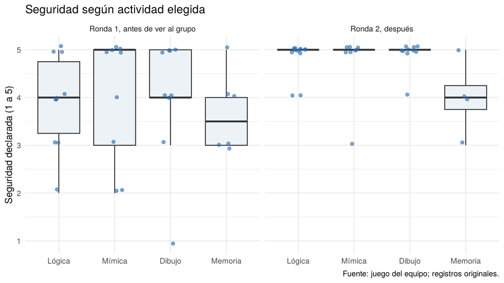

```r
ggplot(largo, aes(x = actividad, y = seguridad)) +
  geom_boxplot(fill = "#EDF2F7", outlier.shape = NA) +
  geom_jitter(width = 0.15, height = 0.08, alpha = 0.6, color = azul) +
  facet_wrap(~ ronda) + theme_minimal() +
  labs(title = "Seguridad según actividad elegida", x = NULL,
       y = "Seguridad declarada (1 a 5)", caption = fuente_juego)
```

```r
largo |> group_by(ronda, actividad) |>
  summarise(N = n(), media = num(mean(seguridad), 2), mediana = median(seguridad),
            .groups = "drop") |>
  kable(caption = "Seguridad por actividad y ronda")
```

Seguridad por actividad y ronda

| ronda | actividad | N | media | mediana |
| --- | --- | --- | --- | --- |
| Ronda 1, antes de ver al grupo | Lógica | 10 | 3,90 | 4.0 |
| Ronda 1, antes de ver al grupo | Mímica | 9 | 4,00 | 5.0 |
| Ronda 1, antes de ver al grupo | Dibujo | 9 | 4,00 | 4.0 |
| Ronda 1, antes de ver al grupo | Memoria | 6 | 3,67 | 3.5 |
| Ronda 2, después | Lógica | 12 | 4,83 | 5.0 |
| Ronda 2, después | Mímica | 8 | 4,75 | 5.0 |
| Ronda 2, después | Dibujo | 10 | 4,90 | 5.0 |
| Ronda 2, después | Memoria | 4 | 4,00 | 4.0 |

En la segunda ronda las cajas de Lógica, Mímica y Dibujo colapsan en 5: es la concentración de respuestas en el máximo, no un error de la gráfica. Memoria, con pocos registros, queda más abajo.

# 5. Aumentar y preparar

## Aumentación de datos

Recién después de describir y graficar aplicamos la función `augment_boot()` de la plantilla de la clase 15 a la **tabla original del juego**: remuestrea con reposición filas completas, con sus cuatro respuestas y su código. Mantener el código permite unir después cada copia con la encuesta del mismo participante; encuesta y juego no se sortean por separado, porque eso rompería la correspondencia entre personas.

```r
augment_boot <- function(data, n_new, noise = 0.1) {
  idx <- sample(nrow(data), n_new, replace = TRUE)
  out <- data[idx, ]
  num_cols <- names(out)[sapply(out, is.numeric)]
  for (v in num_cols) out[[v]] <- out[[v]] + rnorm(n_new, 0, noise * sd(data[[v]]))
  out
}
set.seed(123)
juego_boot <- augment_boot(juego_crudo, n_new = 200, noise = 0)

tibble(base = c("Juego original", "Juego remuestreado"),
       filas = c(nrow(juego_crudo), nrow(juego_boot)),
       codigos_distintos = c(n_distinct(juego_crudo$id), n_distinct(juego_boot$id))) |>
  kable(caption = "Aumentación por remuestreo: 200 filas, semilla 123, ruido 0")
```

Aumentación por remuestreo: 200 filas, semilla 123, ruido 0

| base | filas | codigos_distintos |
| --- | --- | --- |
| Juego original | 34 | 34 |
| Juego remuestreado | 200 | 34 |

Usamos `noise = 0` porque las respuestas son categorías o escalas ordinales: el ruido normal produciría decimales y valores fuera de sus códigos. **Las 200 filas no son personas nuevas**: provienen de los mismos 34 códigos. No crean una muestra independiente, no validan el modelo con personas nuevas y no corrigen la representatividad. Solo se usan en el paso 7 para mostrar la pseudorreplicación.

## Selección de observaciones

```r
encuesta <- encuesta_cruda |> filter(consentimiento == 1)

# Una respuesta por participante: la primera en el orden del archivo, con
# distinct() como en la clase 7. En el paso 7 se repite con la última.
encuesta_personas <- encuesta |> distinct(id, .keep_all = TRUE)

tibble(
  etapa = c("Encuesta original", "Con consentimiento", "Una respuesta por código", "Juego"),
  filas = c(nrow(encuesta_cruda), nrow(encuesta), nrow(encuesta_personas), nrow(juego_crudo))
) |> kable(caption = "Filas en cada etapa de la selección")
```

Filas en cada etapa de la selección

| etapa | filas |
| --- | --- |
| Encuesta original | 39 |
| Con consentimiento | 39 |
| Una respuesta por código | 36 |
| Juego | 34 |

Todas las respuestas aceptaron participar. Para analizar personas conservamos **la primera respuesta de cada código**: es una regla explícita, no una afirmación de que esa respuesta sea la correcta. Las 3 segundas respuestas se usan en la prueba de sensibilidad del paso 7.

## Unión por código

Unimos con `left_join()`, con la encuesta a la izquierda, por el código `id`. Antes verificamos que cada código aparezca una sola vez en cada tabla.

```r
stopifnot(!anyDuplicated(encuesta_personas$id), !anyDuplicated(juego_crudo$id))
base <- left_join(encuesta_personas, juego_crudo, by = "id")

tibble(
  control = c("Códigos en la encuesta", "Códigos en el juego", "Filas después de unir",
              "Códigos con encuesta y juego", "Encuestados sin correspondencia en el juego",
              "Registros del juego sin encuesta"),
  N = c(nrow(encuesta_personas), nrow(juego_crudo), nrow(base),
        sum(encuesta_personas$id %in% juego_crudo$id),
        sum(!encuesta_personas$id %in% juego_crudo$id),
        sum(!juego_crudo$id %in% encuesta_personas$id))
) |> kable(caption = "Control de la unión")
```

Control de la unión

| control | N |
| --- | --- |
| Códigos en la encuesta | 36 |
| Códigos en el juego | 34 |
| Filas después de unir | 36 |
| Códigos con encuesta y juego | 34 |
| Encuestados sin correspondencia en el juego | 2 |
| Registros del juego sin encuesta | 0 |

La unión no cambió la cantidad de filas. **Dos encuestados no tienen correspondencia en el juego**: sus columnas del juego quedan como NA, que no equivale a “no cambió de voto”, y se excluyen de los análisis del juego. Ningún registro del juego quedó sin encuesta.

## Indicadores de cambio

Los indicadores no eran preguntas: se calculan ahora, a partir de respuestas existentes y sobre los participantes con ambas fuentes.

| Indicador | Cálculo | Qué representa |
| --- | --- | --- |
| `cambio_voto` | 1 si la actividad de la ronda 1 difiere de la de la ronda 2 | Cambio de actividad |
| `cambio_seguridad` | Seguridad ronda 2 − seguridad ronda 1 | Variación en puntos de la escala |
| `hacia_mas_votada` | 1 si cambió y en la ronda 2 eligió la más votada de la ronda 1 | Cambio en dirección de la mayoría relativa |

```r
mas_votada_r1 <- as.integer(names(which.max(table(juego_crudo$ronda1_eleccion))))
preparar <- function(datos) {
  datos |> mutate(
    cambio_voto = as.integer(ronda1_eleccion != ronda2_eleccion),
    cambio_seguridad = ronda2_seguridad - ronda1_seguridad,
    hacia_mas_votada = as.integer(cambio_voto == 1 & ronda2_eleccion == mas_votada_r1)
  )
}
cruce <- base |> filter(id %in% juego_crudo$id) |> preparar()
kable(perfil(cruce |> select(id, ronda1_eleccion:hacia_mas_votada)),
      caption = paste0("Segundo perfilado: participantes con ambas fuentes (", nrow(cruce), ")"))
```

Segundo perfilado: participantes con ambas fuentes (34)

| variable | tipo | distintos | faltantes | minimo | maximo |
| --- | --- | --- | --- | --- | --- |
| id | character | 34 | 0 | NA | NA |
| ronda1_eleccion | numeric | 4 | 0 | 1 | 4 |
| ronda1_seguridad | numeric | 5 | 0 | 1 | 5 |
| ronda2_eleccion | numeric | 4 | 0 | 1 | 4 |
| ronda2_seguridad | numeric | 3 | 0 | 3 | 5 |
| cambio_voto | integer | 2 | 0 | 0 | 1 |
| cambio_seguridad | numeric | 6 | 0 | -1 | 4 |
| hacia_mas_votada | integer | 2 | 0 | 0 | 1 |

# 6. Asociación y cambios entre rondas

## Cambios entre rondas

```r
tibble(
  medida = c("Participantes con encuesta y juego",
             "Cambiaron de actividad",
             paste0("De ellos, hacia la más votada de la ronda 1 (", etq_actividad[mas_votada_r1], ")"),
             "Seguridad media, ronda 1", "Seguridad media, ronda 2",
             "Cambio medio de seguridad (puntos)", "Cambio mediano de seguridad (puntos)",
             "Aumentaron su seguridad", "La mantuvieron", "La redujeron"),
  valor = c(nrow(cruce), sum(cruce$cambio_voto), sum(cruce$hacia_mas_votada),
            num(mean(cruce$ronda1_seguridad), 2), num(mean(cruce$ronda2_seguridad), 2),
            num(mean(cruce$cambio_seguridad), 2), num(median(cruce$cambio_seguridad), 0),
            sum(cruce$cambio_seguridad > 0), sum(cruce$cambio_seguridad == 0),
            sum(cruce$cambio_seguridad < 0))
) |> kable(caption = "Cambios entre la primera y la segunda ronda")
```

Cambios entre la primera y la segunda ronda

| medida | valor |
| --- | --- |
| Participantes con encuesta y juego | 34 |
| Cambiaron de actividad | 11 |
| De ellos, hacia la más votada de la ronda 1 (Lógica) | 5 |
| Seguridad media, ronda 1 | 3,91 |
| Seguridad media, ronda 2 | 4,74 |
| Cambio medio de seguridad (puntos) | 0,82 |
| Cambio mediano de seguridad (puntos) | 1 |
| Aumentaron su seguridad | 18 |
| La mantuvieron | 13 |
| La redujeron | 3 |

**La seguridad declarada subió entre rondas:** en promedio 0,82 puntos; 18 participantes la aumentaron, 13 la mantuvieron y 3 la redujeron. Es una comparación antes y después **sin grupo de comparación**: no separa el efecto de conocer la votación del grupo del de responder por segunda vez. La diferencia es un cálculo entre dos respuestas ordinales, no una pregunta hecha directamente.

**Cambios de voto:** 11 de 34 (32,4 %) cambiaron de actividad y 5 de ellos eligieron la más votada de la primera ronda. Con este diseño **no podemos establecer si siguieron a la mayoría**: en la primera ronda no hubo una mayoría clara y cambiar de actividad también puede reflejar una reconsideración, una preferencia débil o la interpretación de las reglas.

## Adaptación de la vestimenta y cambio de voto

Siguiendo el bloque categórica por categórica de la plantilla, cruzamos cambiar la ropa según con quién se estará con cambiar de voto. Revisamos las frecuencias esperadas del chi-cuadrado, usamos el test exacto de Fisher, válido con celdas pequeñas, e informamos phi como medida de magnitud.

```r
tab <- table(Adapta_ropa = factor(cruce$cambia_segun_personas, 0:1, c("No", "Sí")),
             Cambio_voto = factor(cruce$cambio_voto, 0:1, c("Mantuvo", "Cambió")))
tab
```

```
##            Cambio_voto
## Adapta_ropa Mantuvo Cambió
##          No      12      4
##          Sí      11      7
```

```r
chi <- suppressWarnings(chisq.test(tab, correct = FALSE))
round(chi$expected, 2)
```

```
##            Cambio_voto
## Adapta_ropa Mantuvo Cambió
##          No   10.82   5.18
##          Sí   12.18   5.82
```

```r
fisher_cambio <- fisher.test(tab)
phi_cambio <- sqrt(as.numeric(chi$statistic) / sum(tab))  # phi = raíz de (chi-cuadrado / N)

cruce |> group_by(Adapta_ropa = factor(cambia_segun_personas, 0:1, c("No", "Sí"))) |>
  summarise(N = n(), cambiaron = sum(cambio_voto),
            porcentaje = num(100 * mean(cambio_voto), 1), .groups = "drop") |>
  kable(caption = "Cambio de voto según adaptación de la vestimenta")
```

Cambio de voto según adaptación de la vestimenta

| Adapta_ropa | N | cambiaron | porcentaje |
| --- | --- | --- | --- |
| No | 16 | 4 | 25,0 |
| Sí | 18 | 7 | 38,9 |

Cambió de actividad el 38,9 % de quienes adaptan su ropa y el 25,0 % de quienes no. La menor frecuencia esperada es 5,18. Fisher da p = 0,477 y phi vale 0,15, una magnitud pequeña. **No encontramos evidencia suficiente de asociación**; eso no demuestra que la relación no exista, y el cruce no se interpreta como un efecto de la vestimenta sobre el voto.

# 7. Modelo

## Variables y especificación

| Rol | Variable | Pregunta | Escala |
| --- | --- | --- | --- |
| Y | `ronda1_seguridad` | Seguridad de la elección en la ronda 1, antes de ver al grupo | 1 a 5 |
| X₁ | `confianza_ropa` | En qué medida la vestimenta influye en la confianza durante el día | 1 No influye · 2 Impacto moderado · 3 Influye significativamente |
| X₂ | `cambia_segun_personas` | Cambia la ropa según con quién estará | 0 No · 1 Sí |

**Por qué estas variables.** X₁ es la pregunta más cercana al vínculo entre apariencia y seguridad; X₂ capta la adaptación al contexto social. Usamos la seguridad de la ronda 1 para no mezclar el efecto de la devolución del grupo. Las variables se eligieron por la pregunta del proyecto, no para conseguir significación.

**Limitación.** `lm()`, como en la clase 12, trata las escalas ordinales como numéricas: supone que las distancias entre sus categorías son iguales. Por eso, como respaldo, estimamos también un modelo con la confianza como factor.

```r
df <- cruce |> select(ronda1_seguridad, confianza_ropa, cambia_segun_personas) |> na.omit()
modelo <- lm(ronda1_seguridad ~ confianza_ropa + cambia_segun_personas, data = df)
summary(modelo)
```

```
##
## Call:
## lm(formula = ronda1_seguridad ~ confianza_ropa + cambia_segun_personas,
##     data = df)
##
## Residuals:
##      Min       1Q   Median       3Q      Max
## -2.29691 -0.74062  0.02208  0.78477  1.70309
##
## Coefficients:
##                       Estimate Std. Error t value Pr(>|t|)
## (Intercept)             5.1026     0.7782   6.557 2.54e-07 ***
## confianza_ropa         -0.4437     0.3536  -1.255    0.219
## cambia_segun_personas  -0.4746     0.3750  -1.265    0.215
## ---
## Signif. codes:  0 '***' 0.001 '**' 0.01 '*' 0.05 '.' 0.1 ' ' 1
##
## Residual standard error: 1.086 on 31 degrees of freedom
## Multiple R-squared:  0.102,  Adjusted R-squared:  0.04409
## F-statistic: 1.761 on 2 and 31 DF,  p-value: 0.1886
```

```r
coefs <- summary(modelo)$coefficients
r2 <- summary(modelo)$r.squared

# Intervalos del 95 % aproximados de la clase: coeficiente ± 2 errores estándar.
tabla_coef <- function(m) {
  s <- summary(m)$coefficients
  tibble(termino = c("Intercepto", "X₁ confianza", "X₂ adapta"),
         coeficiente = round(s[, 1], 3), error_estandar = round(s[, 2], 3),
         IC95_inferior = round(s[, 1] - 2 * s[, 2], 3),
         IC95_superior = round(s[, 1] + 2 * s[, 2], 3),
         p_valor = signif(s[, 4], 3))
}
kable(tabla_coef(modelo), caption = paste0("Modelo original (N = ", nrow(df), ")"))
```

Modelo original (N = 34)

[output not shown]

- **X₁, influencia de la ropa:** -0,44 puntos de seguridad inicial por cada punto más en la escala, manteniendo fija la adaptación (IC aprox. -1,15 a 0,26; p = 0,219).
- **X₂, adaptación de la ropa:** -0,47 puntos al comparar sí con no, al mismo nivel de confianza (IC aprox. -1,22 a 0,28; p = 0,215).
- **R² = 0,102:** las dos variables recogen el 10,2 % de la variación de la seguridad inicial.

Ambos intervalos incluyen el cero: **no encontramos evidencia suficiente de asociación** entre estas dos variables de vestimenta y la seguridad inicial. Esto no demuestra que la vestimenta sea irrelevante para otras decisiones, y el modelo no analiza si el aumento de seguridad entre rondas se relaciona con la ropa. Son asociaciones, no efectos causales; el intercepto evalúa confianza = 0, fuera de la escala.

## Respaldo del modelo

**Confianza como factor.** Evita suponer distancias iguales entre sus tres categorías.

```r
modelo_factor <- lm(ronda1_seguridad ~ factor(confianza_ropa) + cambia_segun_personas, data = df)
f <- summary(modelo_factor)$fstatistic
summary(modelo_factor)$coefficients |> round(3) |>
  kable(caption = "Modelo con la confianza como factor (referencia: No influye)")
```

Modelo con la confianza como factor (referencia: No influye)

|  | Estimate | Std. Error | t value | Pr(>\|t\|) |
| --- | --- | --- | --- | --- |
| (Intercept) | 4.649 | 0.688 | 6.754 | 0.000 |
| factor(confianza_ropa)2 | -0.432 | 0.681 | -0.634 | 0.531 |
| factor(confianza_ropa)3 | -0.882 | 0.762 | -1.157 | 0.256 |
| cambia_segun_personas | -0.473 | 0.389 | -1.216 | 0.234 |

R² = 0,102; la prueba global da p = 0,350.

**Residuos.** Como en la clase 12, miramos lo que el modelo deja sin explicar. Los valores 1 y 5 son extremos válidos de la escala y no se eliminan.

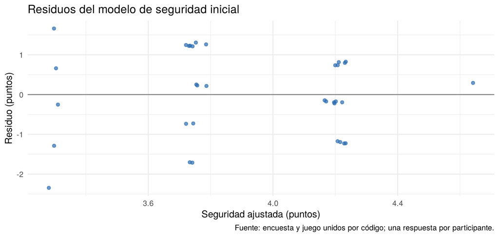

```r
df_res <- df |> mutate(predicho = fitted(modelo), residuo = resid(modelo))
ggplot(df_res, aes(x = predicho, y = residuo)) +
  geom_hline(yintercept = 0, color = "grey50") +
  geom_jitter(width = 0.02, height = 0.05, alpha = 0.7, color = azul) +
  theme_minimal() +
  labs(title = "Residuos del modelo de seguridad inicial",
       x = "Seguridad ajustada (puntos)", y = "Residuo (puntos)", caption = fuente_cruce)
```

El error estándar residual es 1,09 puntos y los residuos van de -2,30 a 1,70. Un ajuste bajo también es informativo: la seguridad al elegir una actividad puede depender de habilidades, preferencias o vínculos con el grupo que la encuesta no mide.

**Sensibilidad a las respuestas repetidas.** Repetimos el modelo con la última respuesta de cada código en lugar de la primera.

```r
encuesta_ultima <- encuesta |> filter(!duplicated(id, fromLast = TRUE))
df_ultima <- left_join(encuesta_ultima, juego_crudo, by = "id") |>
  filter(id %in% juego_crudo$id) |>
  select(ronda1_seguridad, confianza_ropa, cambia_segun_personas) |> na.omit()
modelo_ultima <- lm(ronda1_seguridad ~ confianza_ropa + cambia_segun_personas, data = df_ultima)

tibble(respuesta = c("Primera", "Última"), N = c(nrow(df), nrow(df_ultima)),
       beta_confianza = round(c(coef(modelo)[2], coef(modelo_ultima)[2]), 3),
       beta_adaptacion = round(c(coef(modelo)[3], coef(modelo_ultima)[3]), 3),
       R2 = round(c(r2, summary(modelo_ultima)$r.squared), 3)) |>
  kable(caption = "Modelo con la primera y con la última respuesta de cada código")
```

Modelo con la primera y con la última respuesta de cada código

| respuesta | N | beta_confianza | beta_adaptacion | R2 |
| --- | --- | --- | --- | --- |
| Primera | 34 | -0.444 | -0.475 | 0.102 |
| Última | 34 | -0.440 | -0.595 | 0.128 |

La lectura no cambia con esta decisión.

## Modelo sobre la base aumentada: pseudorreplicación

Unimos cada fila remuestreada del juego con la respuesta de encuesta seleccionada de su mismo código y ajustamos la misma regresión. Mantenemos Y y X iguales; solo cambia el conjunto de filas.

```r
df_boot <- left_join(juego_boot, encuesta_personas, by = "id") |>
  select(ronda1_seguridad, confianza_ropa, cambia_segun_personas) |> na.omit()
modelo_boot <- lm(ronda1_seguridad ~ confianza_ropa + cambia_segun_personas, data = df_boot)
cb <- summary(modelo_boot)$coefficients

bind_rows(tabla_coef(modelo) |> mutate(base = paste0("Original (", nrow(df), " filas)")),
          tabla_coef(modelo_boot) |> mutate(base = paste0("Aumentada (", nrow(df_boot), " filas)"))) |>
  filter(termino != "Intercepto") |>
  select(base, everything()) |>
  kable(caption = "Coeficientes, errores estándar, intervalos (± 2 EE) y p-valores")
```

Coeficientes, errores estándar, intervalos (± 2 EE) y p-valores

| base | termino | coeficiente | error_estandar | IC95_inferior | IC95_superior | p_valor |
| --- | --- | --- | --- | --- | --- | --- |
| Original (34 filas) | X₁ confianza | -0.444 | 0.354 | -1.151 | 0.263 | 0.219000 |
| Original (34 filas) | X₂ adapta | -0.475 | 0.375 | -1.225 | 0.275 | 0.215000 |
| Aumentada (200 filas) | X₁ confianza | -0.556 | 0.154 | -0.863 | -0.249 | 0.000377 |
| Aumentada (200 filas) | X₂ adapta | -0.400 | 0.150 | -0.700 | -0.100 | 0.008250 |

```r
tibble(base = c("Original", "Aumentada"), filas = c(nrow(df), nrow(df_boot)),
       codigos_originales = c(nrow(df), n_distinct(juego_boot$id)),
       R2 = round(c(r2, summary(modelo_boot)$r.squared), 3)) |>
  kable(caption = "R² y códigos originales detrás de cada base")
```

R² y códigos originales detrás de cada base

| base | filas | codigos_originales | R2 |
| --- | --- | --- | --- |
| Original | 34 | 34 | 0.102 |
| Aumentada | 200 | 34 | 0.099 |

En la base aumentada el error estándar de X₁ pasa de 0,354 a 0,154 y su p-valor de 0,219 a menos de 0,001; el intervalo deja de incluir el cero. **Es pseudorreplicación**: tratar las copias de los mismos 34 participantes como unidades independientes achica artificialmente los errores estándar y los p-valores sin agregar información; el R² prácticamente no cambia (0,102 frente a 0,099). Los coeficientes varían según qué filas salieron sorteadas y cuántas veces. Las conclusiones se apoyan en el modelo original.

# 8. Comunicar

**Público.** La clase y la profesora: lectores con conocimientos básicos de análisis de datos que no conocen la base ni el procedimiento de recolección.

**Afirmación central.** *En este grupo, la seguridad declarada en el juego subió después de ver los resultados del grupo y el cuidado personal difiere entre las respuestas de mujeres y hombres; con dos variables de vestimenta no encontramos evidencia suficiente para explicar la seguridad inicial, y el diseño no permite establecer si hubo seguimiento de la mayoría.*

## Lo que encontramos

1. **La seguridad subió entre rondas:** 0,82 puntos en promedio; en la segunda ronda 27 de 34 registros (79,4 %) marcaron el máximo. Descriptivo y sin grupo de comparación.
2. **Cambios de voto:** 11 de 34, en una primera ronda sin mayoría clara; no podemos establecer si siguieron a la mayoría.
3. **Modelo:** R² = 0,10 y ambos intervalos incluyen el cero; no encontramos evidencia suficiente de asociación entre la influencia de la ropa o la adaptación al contexto y la seguridad inicial.
4. **Cuidado personal por sexo:** diferencias descriptivas en peluquería, influencia de la ropa en la confianza, repetición de outfit y compras.
5. **Aumentación:** 200 filas remuestreadas dan una precisión aparente que no corresponde a información nueva.

## Límites

- **Muestra no aleatoria.** 34 participantes con ambos instrumentos, del entorno del equipo y concentrados en dos carreras. No generalizamos a la universidad ni sabemos cómo respondería otra muestra.
- **Sin grupo de comparación.** El antes y después no separa ver al grupo de votar por segunda vez; el juego no asignó al azar quién veía los resultados.
- **Alcance del modelo.** Solo analiza la seguridad inicial con dos variables de vestimenta; no analiza si el aumento de seguridad se relaciona con la ropa.
- **Un test no significativo no prueba que dos grupos sean iguales.**
- **Poca variación.** La confianza en la ropa se concentra en “impacto moderado” y la seguridad de la segunda ronda en 5.
- **Origen de los registros.** La aumentación no crea una muestra independiente, no valida con personas nuevas ni corrige la representatividad. Los archivos no tienen una columna que distinga observados de sintéticos, y no registramos invitaciones ni rechazos.

## Objeción principal

**La objeción más fuerte es de medición.** Cuidar la apariencia, adaptar la ropa al contexto y elegir entre Lógica, Mímica, Dibujo o Memoria son conductas distintas. No encontrar la relación esperada no permite concluir que la apariencia no se relacione con la influencia social en otros contextos.

## Qué haríamos diferente

- **Pilotear el juego antes de cerrar la encuesta**, para que ambos instrumentos midan aspectos comparables, cuidando que uno no condicione al otro.
- **Una decisión ligada a la imagen**, por ejemplo entre atuendos, y registrar por qué cambia cada elección.
- **Revisar la escala de seguridad** con un piloto (instrucciones y anclajes), dada la concentración en 5, sin modificar respuestas ya recogidas.
- **Mejorar las preguntas de tiempo:** agregar el tramo de 30 a 60 minutos y evitar categorías solapadas como “la noche anterior” y “un día antes”.
- **Un grupo de comparación** con asignación aleatoria de quién ve los resultados antes de la segunda ronda.
- **Más casos reales**, con una columna de origen observado o sintético y registro de invitaciones y no respuestas.

Mostrar una mayoría armada de antemano sería otro experimento, que habría que justificar en su diseño; no una forma de conseguir el resultado esperado.

# Anexo — Reproducibilidad y material del curso

## Cómo reproducir el informe

1. Clonar el repositorio del equipo y abrir el proyecto de RStudio, que fija la raíz desde la que `here()` construye las rutas.
2. Instalar los paquetes una sola vez (primer bloque de código) y reiniciar R.
3. Abrir este archivo y ejecutar **Knit**.

El informe lee únicamente los CSV de `datos/` y no los modifica. Usa la misma selección, unión, aumentación y modelo que `codigo/proyecto_encuesta_juego.Rmd`.

## Material del curso utilizado

| Material | Uso en este informe |
| --- | --- |
| `clases/clase8/pautas_equipos.qmd` | Pasos de trabajo, límites y objeción principal |
| `clases/clase15/analisis datos experimento.Rmd` | Tabla descriptiva, Fisher, phi y aumentación por remuestreo |
| Clase *Análisis de datos de una encuesta o experimento* | Frecuencias esperadas, phi, pseudorreplicación e intervalos ± 2 EE |
| `clases/clase5/clase5_cargadatos2.R` | Perfilado con tipos, valores distintos y faltantes |
| `clases/clase6/clase_diseno_encuestas.qmd` | Tipos de variable, faltantes y diccionario |
| `clases/clase7/carga_y_transformacion.R` | Duplicados y `distinct()` |
| `clases/clase9/union_y_graficos_por_grupo.R` | Uniones y gráficos por grupo |
| `clases/clase9/visualizacion_densidad_barras_caja.R` | Gráficos de barras y de caja |
| `clases/clase12/analisis_transito_aire.R` | Regresión múltiple, factores, R² y residuos |